# Risk Factor Analysis

## Outcome Variable

**Outcome Variable:** pers_wast

## Predictor Variables

**Intervention Variable:** meducyrs

**Adjustment Set:**

unadjusted

## Stratifying Variables

The analysis was stratified on these variable(s):

- agecat
- studyid
- country

## Data Summary

| agecat | studyid | country | meducyrs | pers_wast | n_cell | n |
| --- | --- | --- | --- | --- | --- | --- |
| 0-24 months | ki0047075b-MAL-ED | BANGLADESH | Low | 0 | 62 | 202 |
| 0-24 months | ki0047075b-MAL-ED | BANGLADESH | Low | 1 | 4 | 202 |
| 0-24 months | ki0047075b-MAL-ED | BANGLADESH | Medium | 0 | 59 | 202 |
| 0-24 months | ki0047075b-MAL-ED | BANGLADESH | Medium | 1 | 2 | 202 |
| 0-24 months | ki0047075b-MAL-ED | BANGLADESH | High | 0 | 71 | 202 |
| 0-24 months | ki0047075b-MAL-ED | BANGLADESH | High | 1 | 4 | 202 |
| 0-24 months | ki0047075b-MAL-ED | BRAZIL | Low | 0 | 59 | 216 |
| 0-24 months | ki0047075b-MAL-ED | BRAZIL | Low | 1 | 1 | 216 |
| 0-24 months | ki0047075b-MAL-ED | BRAZIL | Medium | 0 | 81 | 216 |
| 0-24 months | ki0047075b-MAL-ED | BRAZIL | Medium | 1 | 1 | 216 |
| 0-24 months | ki0047075b-MAL-ED | BRAZIL | High | 0 | 74 | 216 |
| 0-24 months | ki0047075b-MAL-ED | BRAZIL | High | 1 | 0 | 216 |
| 0-24 months | ki0047075b-MAL-ED | INDIA | Low | 0 | 63 | 210 |
| 0-24 months | ki0047075b-MAL-ED | INDIA | Low | 1 | 10 | 210 |
| 0-24 months | ki0047075b-MAL-ED | INDIA | Medium | 0 | 72 | 210 |
| 0-24 months | ki0047075b-MAL-ED | INDIA | Medium | 1 | 5 | 210 |
| 0-24 months | ki0047075b-MAL-ED | INDIA | High | 0 | 56 | 210 |
| 0-24 months | ki0047075b-MAL-ED | INDIA | High | 1 | 4 | 210 |
| 0-24 months | ki0047075b-MAL-ED | NEPAL | Low | 0 | 93 | 223 |
| 0-24 months | ki0047075b-MAL-ED | NEPAL | Low | 1 | 1 | 223 |
| 0-24 months | ki0047075b-MAL-ED | NEPAL | Medium | 0 | 74 | 223 |
| 0-24 months | ki0047075b-MAL-ED | NEPAL | Medium | 1 | 2 | 223 |
| 0-24 months | ki0047075b-MAL-ED | NEPAL | High | 0 | 53 | 223 |
| 0-24 months | ki0047075b-MAL-ED | NEPAL | High | 1 | 0 | 223 |
| 0-24 months | ki0047075b-MAL-ED | PERU | Low | 0 | 98 | 283 |
| 0-24 months | ki0047075b-MAL-ED | PERU | Low | 1 | 0 | 283 |
| 0-24 months | ki0047075b-MAL-ED | PERU | Medium | 0 | 99 | 283 |
| 0-24 months | ki0047075b-MAL-ED | PERU | Medium | 1 | 1 | 283 |
| 0-24 months | ki0047075b-MAL-ED | PERU | High | 0 | 85 | 283 |
| 0-24 months | ki0047075b-MAL-ED | PERU | High | 1 | 0 | 283 |

[output cut: 348 more lines]

The following strata were considered:

- agecat: 0-24 months, studyid: ki0047075b-MAL-ED, country: BANGLADESH
- agecat: 0-24 months, studyid: ki0047075b-MAL-ED, country: BRAZIL
- agecat: 0-24 months, studyid: ki0047075b-MAL-ED, country: INDIA
- agecat: 0-24 months, studyid: ki0047075b-MAL-ED, country: NEPAL
- agecat: 0-24 months, studyid: ki0047075b-MAL-ED, country: PERU
- agecat: 0-24 months, studyid: ki0047075b-MAL-ED, country: SOUTH AFRICA
- agecat: 0-24 months, studyid: ki0047075b-MAL-ED, country: TANZANIA, UNITED REPUBLIC OF
- agecat: 0-24 months, studyid: ki1000108-CMC-V-BCS-2002, country: INDIA
- agecat: 0-24 months, studyid: ki1000108-IRC, country: INDIA
- agecat: 0-24 months, studyid: ki1000109-EE, country: PAKISTAN
- agecat: 0-24 months, studyid: ki1000304b-SAS-CompFeed, country: INDIA
- agecat: 0-24 months, studyid: ki1000304b-SAS-FoodSuppl, country: INDIA
- agecat: 0-24 months, studyid: ki1017093-NIH-Birth, country: BANGLADESH
- agecat: 0-24 months, studyid: ki1017093b-PROVIDE, country: BANGLADESH
- agecat: 0-24 months, studyid: ki1017093c-NIH-Crypto, country: BANGLADESH
- agecat: 0-24 months, studyid: ki1066203-TanzaniaChild2, country: TANZANIA, UNITED REPUBLIC OF
- agecat: 0-24 months, studyid: ki1112895-Guatemala BSC, country: GUATEMALA
- agecat: 0-24 months, studyid: ki1113344-GMS-Nepal, country: NEPAL
- agecat: 0-24 months, studyid: ki1119695-PROBIT, country: BELARUS
- agecat: 0-24 months, studyid: ki1126311-ZVITAMBO, country: ZIMBABWE
- agecat: 0-24 months, studyid: ki1135781-COHORTS, country: GUATEMALA
- agecat: 0-24 months, studyid: ki1135781-COHORTS, country: INDIA
- agecat: 0-24 months, studyid: ki1135781-COHORTS, country: PHILIPPINES
- agecat: 0-24 months, studyid: ki1148112-LCNI-5, country: MALAWI
- agecat: 0-24 months, studyid: kiGH5241-JiVitA-3, country: BANGLADESH
- agecat: 0-24 months, studyid: kiGH5241-JiVitA-4, country: BANGLADESH
- agecat: 0-6 months, studyid: ki0047075b-MAL-ED, country: BANGLADESH
- agecat: 0-6 months, studyid: ki0047075b-MAL-ED, country: BRAZIL
- agecat: 0-6 months, studyid: ki0047075b-MAL-ED, country: INDIA
- agecat: 0-6 months, studyid: ki0047075b-MAL-ED, country: NEPAL
- agecat: 0-6 months, studyid: ki0047075b-MAL-ED, country: PERU
- agecat: 0-6 months, studyid: ki0047075b-MAL-ED, country: SOUTH AFRICA
- agecat: 0-6 months, studyid: ki0047075b-MAL-ED, country: TANZANIA, UNITED REPUBLIC OF
- agecat: 0-6 months, studyid: ki1000108-CMC-V-BCS-2002, country: INDIA
- agecat: 0-6 months, studyid: ki1000108-IRC, country: INDIA
- agecat: 0-6 months, studyid: ki1000109-EE, country: PAKISTAN
- agecat: 0-6 months, studyid: ki1017093b-PROVIDE, country: BANGLADESH
- agecat: 0-6 months, studyid: ki1066203-TanzaniaChild2, country: TANZANIA, UNITED REPUBLIC OF
- agecat: 0-6 months, studyid: ki1113344-GMS-Nepal, country: NEPAL
- agecat: 6-24 months, studyid: ki0047075b-MAL-ED, country: BANGLADESH
- agecat: 6-24 months, studyid: ki0047075b-MAL-ED, country: BRAZIL
- agecat: 6-24 months, studyid: ki0047075b-MAL-ED, country: INDIA
- agecat: 6-24 months, studyid: ki0047075b-MAL-ED, country: NEPAL
- agecat: 6-24 months, studyid: ki0047075b-MAL-ED, country: PERU
- agecat: 6-24 months, studyid: ki0047075b-MAL-ED, country: SOUTH AFRICA
- agecat: 6-24 months, studyid: ki0047075b-MAL-ED, country: TANZANIA, UNITED REPUBLIC OF
- agecat: 6-24 months, studyid: ki1000108-CMC-V-BCS-2002, country: INDIA
- agecat: 6-24 months, studyid: ki1000108-IRC, country: INDIA
- agecat: 6-24 months, studyid: ki1000109-EE, country: PAKISTAN
- agecat: 6-24 months, studyid: ki1000304b-SAS-CompFeed, country: INDIA
- agecat: 6-24 months, studyid: ki1000304b-SAS-FoodSuppl, country: INDIA
- agecat: 6-24 months, studyid: ki1017093-NIH-Birth, country: BANGLADESH
- agecat: 6-24 months, studyid: ki1017093b-PROVIDE, country: BANGLADESH
- agecat: 6-24 months, studyid: ki1017093c-NIH-Crypto, country: BANGLADESH
- agecat: 6-24 months, studyid: ki1066203-TanzaniaChild2, country: TANZANIA, UNITED REPUBLIC OF
- agecat: 6-24 months, studyid: ki1112895-Guatemala BSC, country: GUATEMALA
- agecat: 6-24 months, studyid: ki1113344-GMS-Nepal, country: NEPAL
- agecat: 6-24 months, studyid: ki1119695-PROBIT, country: BELARUS
- agecat: 6-24 months, studyid: ki1126311-ZVITAMBO, country: ZIMBABWE
- agecat: 6-24 months, studyid: ki1135781-COHORTS, country: GUATEMALA
- agecat: 6-24 months, studyid: ki1135781-COHORTS, country: PHILIPPINES
- agecat: 6-24 months, studyid: ki1148112-LCNI-5, country: MALAWI
- agecat: 6-24 months, studyid: kiGH5241-JiVitA-4, country: BANGLADESH

### Dropped Strata

Some strata were dropped due to rare outcomes:

- agecat: 0-24 months, studyid: ki0047075b-MAL-ED, country: BANGLADESH
- agecat: 0-24 months, studyid: ki0047075b-MAL-ED, country: BRAZIL
- agecat: 0-24 months, studyid: ki0047075b-MAL-ED, country: INDIA
- agecat: 0-24 months, studyid: ki0047075b-MAL-ED, country: NEPAL
- agecat: 0-24 months, studyid: ki0047075b-MAL-ED, country: PERU
- agecat: 0-24 months, studyid: ki0047075b-MAL-ED, country: SOUTH AFRICA
- agecat: 0-24 months, studyid: ki0047075b-MAL-ED, country: TANZANIA, UNITED REPUBLIC OF
- agecat: 0-24 months, studyid: ki1000109-EE, country: PAKISTAN
- agecat: 0-24 months, studyid: ki1000304b-SAS-FoodSuppl, country: INDIA
- agecat: 0-24 months, studyid: ki1017093b-PROVIDE, country: BANGLADESH
- agecat: 0-24 months, studyid: ki1017093c-NIH-Crypto, country: BANGLADESH
- agecat: 0-24 months, studyid: ki1066203-TanzaniaChild2, country: TANZANIA, UNITED REPUBLIC OF
- agecat: 0-24 months, studyid: ki1112895-Guatemala BSC, country: GUATEMALA
- agecat: 0-24 months, studyid: ki1148112-LCNI-5, country: MALAWI
- agecat: 0-6 months, studyid: ki0047075b-MAL-ED, country: BANGLADESH
- agecat: 0-6 months, studyid: ki0047075b-MAL-ED, country: BRAZIL
- agecat: 0-6 months, studyid: ki0047075b-MAL-ED, country: NEPAL
- agecat: 0-6 months, studyid: ki0047075b-MAL-ED, country: PERU
- agecat: 0-6 months, studyid: ki0047075b-MAL-ED, country: SOUTH AFRICA
- agecat: 0-6 months, studyid: ki0047075b-MAL-ED, country: TANZANIA, UNITED REPUBLIC OF
- agecat: 0-6 months, studyid: ki1000109-EE, country: PAKISTAN
- agecat: 0-6 months, studyid: ki1017093b-PROVIDE, country: BANGLADESH
- agecat: 0-6 months, studyid: ki1066203-TanzaniaChild2, country: TANZANIA, UNITED REPUBLIC OF
- agecat: 6-24 months, studyid: ki0047075b-MAL-ED, country: BANGLADESH
- agecat: 6-24 months, studyid: ki0047075b-MAL-ED, country: BRAZIL
- agecat: 6-24 months, studyid: ki0047075b-MAL-ED, country: INDIA
- agecat: 6-24 months, studyid: ki0047075b-MAL-ED, country: NEPAL
- agecat: 6-24 months, studyid: ki0047075b-MAL-ED, country: PERU
- agecat: 6-24 months, studyid: ki0047075b-MAL-ED, country: SOUTH AFRICA
- agecat: 6-24 months, studyid: ki0047075b-MAL-ED, country: TANZANIA, UNITED REPUBLIC OF
- agecat: 6-24 months, studyid: ki1000109-EE, country: PAKISTAN
- agecat: 6-24 months, studyid: ki1000304b-SAS-FoodSuppl, country: INDIA
- agecat: 6-24 months, studyid: ki1066203-TanzaniaChild2, country: TANZANIA, UNITED REPUBLIC OF
- agecat: 6-24 months, studyid: ki1112895-Guatemala BSC, country: GUATEMALA
- agecat: 6-24 months, studyid: ki1119695-PROBIT, country: BELARUS
- agecat: 6-24 months, studyid: ki1148112-LCNI-5, country: MALAWI

## Methods Detail

We’re interested in the causal parameters $E[Y_a]$ for all values of $a \in \mathcal{A}$. These parameters represent the mean outcome if, possibly contrary to fact, we intervened to set all units to have $A=a$. Under the randomization and positivity assumptions, these are identified by the statistical parameters $\psi_a=E_W[E_{Y|A,W}(Y|A=a,W)]$. In addition, we’re interested in the mean of $Y$, $E[Y]$ under no intervention (the observed mean). We will estimate these parameters by using SuperLearner to fit the relevant likelihood factors – $E_{Y|A,W}(Y|A=a,W)$ and $p(A=a|W)$, and then updating our likelihood fit using a joint TMLE.

For unadjusted analyses ($W=\{\}$), initial likelihoods were estimated using Lrnr_glm to estimate the simple $E(Y|A)$ and Lrnr_mean to estimate $p(A)$. For adjusted analyses, a small library containing Lrnr_glmnet, Lrnr_xgboost, and Lrnr_mean was used.

Having estimated these parameters, we will then use the delta method to estimate relative risks and attributable risks relative to a prespecified baseline level of $A$.

# Results Detail

## Results Plots

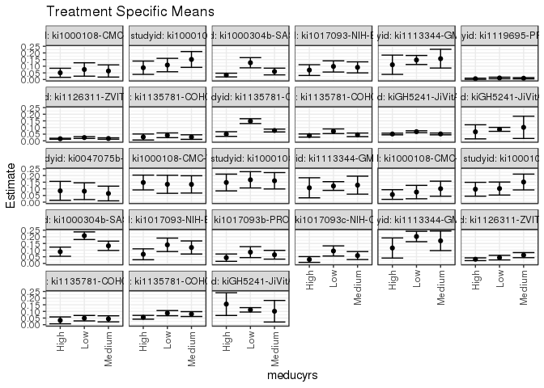

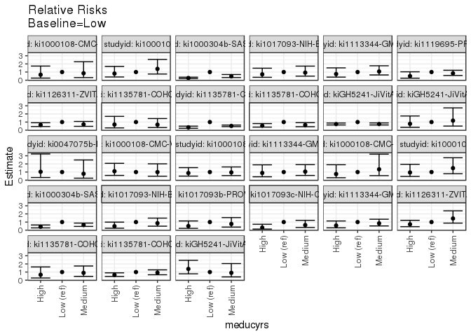

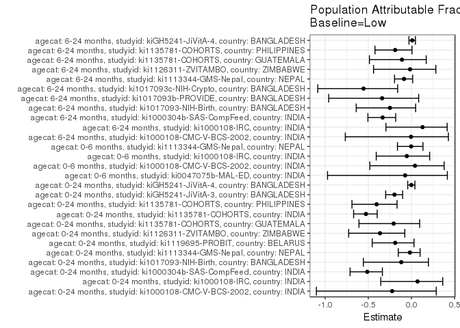

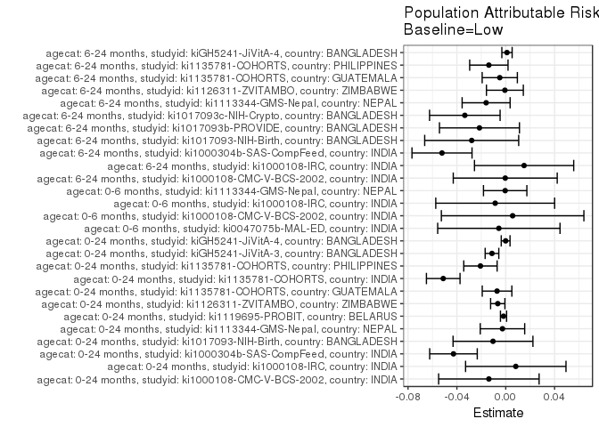

## Results Table

### Parameter: TSM

| agecat | studyid | country | intervention_level | baseline_level | estimate | ci_lower | ci_upper |
| --- | --- | --- | --- | --- | --- | --- | --- |
| 0-24 months | ki1000108-CMC-V-BCS-2002 | INDIA | Low | NA | 0.0754717 | 0.0251181 | 0.1258253 |
| 0-24 months | ki1000108-CMC-V-BCS-2002 | INDIA | Medium | NA | 0.0642202 | 0.0181372 | 0.1103031 |
| 0-24 months | ki1000108-CMC-V-BCS-2002 | INDIA | High | NA | 0.0506329 | 0.0164006 | 0.0848652 |
| 0-24 months | ki1000108-IRC | INDIA | Low | NA | 0.1088435 | 0.0584357 | 0.1592514 |
| 0-24 months | ki1000108-IRC | INDIA | Medium | NA | 0.1510791 | 0.0914708 | 0.2106874 |
| 0-24 months | ki1000108-IRC | INDIA | High | NA | 0.0887097 | 0.0386046 | 0.1388147 |
| 0-24 months | ki1000304b-SAS-CompFeed | INDIA | Low | NA | 0.1262458 | 0.0879874 | 0.1645043 |
| 0-24 months | ki1000304b-SAS-CompFeed | INDIA | Medium | NA | 0.0602151 | 0.0348628 | 0.0855673 |
| 0-24 months | ki1000304b-SAS-CompFeed | INDIA | High | NA | 0.0334448 | 0.0193394 | 0.0475503 |
| 0-24 months | ki1017093-NIH-Birth | BANGLADESH | Low | NA | 0.0984456 | 0.0563758 | 0.1405154 |
| 0-24 months | ki1017093-NIH-Birth | BANGLADESH | Medium | NA | 0.0913978 | 0.0499451 | 0.1328506 |
| 0-24 months | ki1017093-NIH-Birth | BANGLADESH | High | NA | 0.0709677 | 0.0305069 | 0.1114286 |
| 0-24 months | ki1113344-GMS-Nepal | NEPAL | Low | NA | 0.1469880 | 0.1128913 | 0.1810846 |
| 0-24 months | ki1113344-GMS-Nepal | NEPAL | Medium | NA | 0.1568627 | 0.0862268 | 0.2274987 |
| 0-24 months | ki1113344-GMS-Nepal | NEPAL | High | NA | 0.1111111 | 0.0384582 | 0.1837641 |
| 0-24 months | ki1119695-PROBIT | BELARUS | Low | NA | 0.0113960 | 0.0055939 | 0.0171981 |
| 0-24 months | ki1119695-PROBIT | BELARUS | Medium | NA | 0.0095663 | 0.0051043 | 0.0140283 |
| 0-24 months | ki1119695-PROBIT | BELARUS | High | NA | 0.0057678 | 0.0013564 | 0.0101793 |
| 0-24 months | ki1126311-ZVITAMBO | ZIMBABWE | Low | NA | 0.0244524 | 0.0176196 | 0.0312851 |
| 0-24 months | ki1126311-ZVITAMBO | ZIMBABWE | Medium | NA | 0.0173508 | 0.0120858 | 0.0226158 |
| 0-24 months | ki1126311-ZVITAMBO | ZIMBABWE | High | NA | 0.0156219 | 0.0121820 | 0.0190617 |
| 0-24 months | ki1135781-COHORTS | GUATEMALA | Low | NA | 0.0414938 | 0.0236814 | 0.0593061 |
| 0-24 months | ki1135781-COHORTS | GUATEMALA | Medium | NA | 0.0280899 | 0.0109180 | 0.0452618 |
| 0-24 months | ki1135781-COHORTS | GUATEMALA | High | NA | 0.0287081 | 0.0060586 | 0.0513577 |
| 0-24 months | ki1135781-COHORTS | INDIA | Low | NA | 0.1480978 | 0.1299505 | 0.1662451 |
| 0-24 months | ki1135781-COHORTS | INDIA | Medium | NA | 0.0775544 | 0.0669339 | 0.0881748 |
| 0-24 months | ki1135781-COHORTS | INDIA | High | NA | 0.0508197 | 0.0333887 | 0.0682506 |
| 0-24 months | ki1135781-COHORTS | PHILIPPINES | Low | NA | 0.0719340 | 0.0545406 | 0.0893273 |
| 0-24 months | ki1135781-COHORTS | PHILIPPINES | Medium | NA | 0.0451542 | 0.0316460 | 0.0586624 |
| 0-24 months | ki1135781-COHORTS | PHILIPPINES | High | NA | 0.0398104 | 0.0280106 | 0.0516103 |

[output cut: 51 more lines]

### Parameter: E(Y)

| agecat | studyid | country | intervention_level | baseline_level | estimate | ci_lower | ci_upper |
| --- | --- | --- | --- | --- | --- | --- | --- |
| 0-24 months | ki1000108-CMC-V-BCS-2002 | INDIA | NA | NA | 0.0616622 | 0.0372186 | 0.0861058 |
| 0-24 months | ki1000108-IRC | INDIA | NA | NA | 0.1170732 | 0.0859146 | 0.1482317 |
| 0-24 months | ki1000304b-SAS-CompFeed | INDIA | NA | NA | 0.0834553 | 0.0601989 | 0.1067118 |
| 0-24 months | ki1017093-NIH-Birth | BANGLADESH | NA | NA | 0.0880150 | 0.0639627 | 0.1120673 |
| 0-24 months | ki1113344-GMS-Nepal | NEPAL | NA | NA | 0.1443124 | 0.1159091 | 0.1727157 |
| 0-24 months | ki1119695-PROBIT | BELARUS | NA | NA | 0.0095893 | 0.0052864 | 0.0138922 |
| 0-24 months | ki1126311-ZVITAMBO | ZIMBABWE | NA | NA | 0.0179204 | 0.0152268 | 0.0206140 |
| 0-24 months | ki1135781-COHORTS | GUATEMALA | NA | NA | 0.0343840 | 0.0233416 | 0.0454263 |
| 0-24 months | ki1135781-COHORTS | INDIA | NA | NA | 0.0969241 | 0.0882972 | 0.1055510 |
| 0-24 months | ki1135781-COHORTS | PHILIPPINES | NA | NA | 0.0512273 | 0.0430760 | 0.0593786 |
| 0-24 months | kiGH5241-JiVitA-3 | BANGLADESH | NA | NA | 0.0572614 | 0.0531676 | 0.0613553 |
| 0-24 months | kiGH5241-JiVitA-4 | BANGLADESH | NA | NA | 0.0860839 | 0.0717318 | 0.1004359 |
| 0-6 months | ki0047075b-MAL-ED | INDIA | NA | NA | 0.0765550 | 0.0404216 | 0.1126884 |
| 0-6 months | ki1000108-CMC-V-BCS-2002 | INDIA | NA | NA | 0.1396648 | 0.1037072 | 0.1756225 |
| 0-6 months | ki1000108-IRC | INDIA | NA | NA | 0.1592040 | 0.1233945 | 0.1950135 |
| 0-6 months | ki1113344-GMS-Nepal | NEPAL | NA | NA | 0.1205937 | 0.0930759 | 0.1481115 |
| 6-24 months | ki1000108-CMC-V-BCS-2002 | INDIA | NA | NA | 0.0750670 | 0.0482904 | 0.1018437 |
| 6-24 months | ki1000108-IRC | INDIA | NA | NA | 0.1170732 | 0.0859146 | 0.1482317 |
| 6-24 months | ki1000304b-SAS-CompFeed | INDIA | NA | NA | 0.1561462 | 0.1410608 | 0.1712315 |
| 6-24 months | ki1017093-NIH-Birth | BANGLADESH | NA | NA | 0.1117886 | 0.0839169 | 0.1396604 |
| 6-24 months | ki1017093b-PROVIDE | BANGLADESH | NA | NA | 0.0632280 | 0.0437545 | 0.0827015 |
| 6-24 months | ki1017093c-NIH-Crypto | BANGLADESH | NA | NA | 0.0602582 | 0.0425793 | 0.0779372 |
| 6-24 months | ki1113344-GMS-Nepal | NEPAL | NA | NA | 0.1864111 | 0.1545245 | 0.2182978 |
| 6-24 months | ki1126311-ZVITAMBO | ZIMBABWE | NA | NA | 0.0426966 | 0.0342942 | 0.0510990 |
| 6-24 months | ki1135781-COHORTS | GUATEMALA | NA | NA | 0.0441810 | 0.0309524 | 0.0574096 |
| 6-24 months | ki1135781-COHORTS | PHILIPPINES | NA | NA | 0.0731338 | 0.0631985 | 0.0830690 |
| 6-24 months | kiGH5241-JiVitA-4 | BANGLADESH | NA | NA | 0.1129107 | 0.0968835 | 0.1289379 |

### Parameter: RR

| agecat | studyid | country | intervention_level | baseline_level | estimate | ci_lower | ci_upper |
| --- | --- | --- | --- | --- | --- | --- | --- |
| 0-24 months | ki1000108-CMC-V-BCS-2002 | INDIA | Low | Low | 1.0000000 | 1.0000000 | 1.0000000 |
| 0-24 months | ki1000108-CMC-V-BCS-2002 | INDIA | Medium | Low | 0.8509174 | 0.3194153 | 2.2668310 |
| 0-24 months | ki1000108-CMC-V-BCS-2002 | INDIA | High | Low | 0.6708861 | 0.2594960 | 1.7344704 |
| 0-24 months | ki1000108-IRC | INDIA | Low | Low | 1.0000000 | 1.0000000 | 1.0000000 |
| 0-24 months | ki1000108-IRC | INDIA | Medium | Low | 1.3880396 | 0.7553994 | 2.5505102 |
| 0-24 months | ki1000108-IRC | INDIA | High | Low | 0.8150202 | 0.3926031 | 1.6919322 |
| 0-24 months | ki1000304b-SAS-CompFeed | INDIA | Low | Low | 1.0000000 | 1.0000000 | 1.0000000 |
| 0-24 months | ki1000304b-SAS-CompFeed | INDIA | Medium | Low | 0.4769666 | 0.3258875 | 0.6980849 |
| 0-24 months | ki1000304b-SAS-CompFeed | INDIA | High | Low | 0.2649181 | 0.1921362 | 0.3652703 |
| 0-24 months | ki1017093-NIH-Birth | BANGLADESH | Low | Low | 1.0000000 | 1.0000000 | 1.0000000 |
| 0-24 months | ki1017093-NIH-Birth | BANGLADESH | Medium | Low | 0.9284097 | 0.4978603 | 1.7312982 |
| 0-24 months | ki1017093-NIH-Birth | BANGLADESH | High | Low | 0.7208829 | 0.3535298 | 1.4699525 |
| 0-24 months | ki1113344-GMS-Nepal | NEPAL | Low | Low | 1.0000000 | 1.0000000 | 1.0000000 |
| 0-24 months | ki1113344-GMS-Nepal | NEPAL | Medium | Low | 1.0671810 | 0.6430580 | 1.7710302 |
| 0-24 months | ki1113344-GMS-Nepal | NEPAL | High | Low | 0.7559199 | 0.3777117 | 1.5128333 |
| 0-24 months | ki1119695-PROBIT | BELARUS | Low | Low | 1.0000000 | 1.0000000 | 1.0000000 |
| 0-24 months | ki1119695-PROBIT | BELARUS | Medium | Low | 0.8394452 | 0.5790183 | 1.2170049 |
| 0-24 months | ki1119695-PROBIT | BELARUS | High | Low | 0.5061285 | 0.2482131 | 1.0320406 |
| 0-24 months | ki1126311-ZVITAMBO | ZIMBABWE | Low | Low | 1.0000000 | 1.0000000 | 1.0000000 |
| 0-24 months | ki1126311-ZVITAMBO | ZIMBABWE | Medium | Low | 0.7095765 | 0.4697326 | 1.0718839 |
| 0-24 months | ki1126311-ZVITAMBO | ZIMBABWE | High | Low | 0.6388694 | 0.4476167 | 0.9118385 |
| 0-24 months | ki1135781-COHORTS | GUATEMALA | Low | Low | 1.0000000 | 1.0000000 | 1.0000000 |
| 0-24 months | ki1135781-COHORTS | GUATEMALA | Medium | Low | 0.6769663 | 0.3207408 | 1.4288278 |
| 0-24 months | ki1135781-COHORTS | GUATEMALA | High | Low | 0.6918660 | 0.2818027 | 1.6986303 |
| 0-24 months | ki1135781-COHORTS | INDIA | Low | Low | 1.0000000 | 1.0000000 | 1.0000000 |
| 0-24 months | ki1135781-COHORTS | INDIA | Medium | Low | 0.5236699 | 0.4357639 | 0.6293089 |
| 0-24 months | ki1135781-COHORTS | INDIA | High | Low | 0.3431493 | 0.2383972 | 0.4939297 |
| 0-24 months | ki1135781-COHORTS | PHILIPPINES | Low | Low | 1.0000000 | 1.0000000 | 1.0000000 |
| 0-24 months | ki1135781-COHORTS | PHILIPPINES | Medium | Low | 0.6277172 | 0.4272772 | 0.9221855 |
| 0-24 months | ki1135781-COHORTS | PHILIPPINES | High | Low | 0.5534302 | 0.3775183 | 0.8113115 |

[output cut: 51 more lines]

### Parameter: PAR

| agecat | studyid | country | intervention_level | baseline_level | estimate | ci_lower | ci_upper |
| --- | --- | --- | --- | --- | --- | --- | --- |
| 0-24 months | ki1000108-CMC-V-BCS-2002 | INDIA | Low | NA | -0.0138095 | -0.0549421 | 0.0273232 |
| 0-24 months | ki1000108-IRC | INDIA | Low | NA | 0.0082296 | -0.0328770 | 0.0493363 |
| 0-24 months | ki1000304b-SAS-CompFeed | INDIA | Low | NA | -0.0427905 | -0.0622658 | -0.0233152 |
| 0-24 months | ki1017093-NIH-Birth | BANGLADESH | Low | NA | -0.0104306 | -0.0431268 | 0.0222655 |
| 0-24 months | ki1113344-GMS-Nepal | NEPAL | Low | NA | -0.0026756 | -0.0208705 | 0.0155194 |
| 0-24 months | ki1119695-PROBIT | BELARUS | Low | NA | -0.0018067 | -0.0043224 | 0.0007089 |
| 0-24 months | ki1126311-ZVITAMBO | ZIMBABWE | Low | NA | -0.0065320 | -0.0123863 | -0.0006776 |
| 0-24 months | ki1135781-COHORTS | GUATEMALA | Low | NA | -0.0071098 | -0.0192377 | 0.0050181 |
| 0-24 months | ki1135781-COHORTS | INDIA | Low | NA | -0.0511737 | -0.0649288 | -0.0374187 |
| 0-24 months | ki1135781-COHORTS | PHILIPPINES | Low | NA | -0.0207066 | -0.0343611 | -0.0070522 |
| 0-24 months | kiGH5241-JiVitA-3 | BANGLADESH | Low | NA | -0.0112655 | -0.0168525 | -0.0056786 |
| 0-24 months | kiGH5241-JiVitA-4 | BANGLADESH | Low | NA | -0.0000818 | -0.0036753 | 0.0035117 |
| 0-6 months | ki0047075b-MAL-ED | INDIA | Low | NA | -0.0056368 | -0.0557164 | 0.0444429 |
| 0-6 months | ki1000108-CMC-V-BCS-2002 | INDIA | Low | NA | 0.0056442 | -0.0527030 | 0.0639914 |
| 0-6 months | ki1000108-IRC | INDIA | Low | NA | -0.0086282 | -0.0572866 | 0.0400303 |
| 0-6 months | ki1113344-GMS-Nepal | NEPAL | Low | NA | -0.0004589 | -0.0182183 | 0.0173004 |
| 6-24 months | ki1000108-CMC-V-BCS-2002 | INDIA | Low | NA | -0.0004047 | -0.0429651 | 0.0421558 |
| 6-24 months | ki1000108-IRC | INDIA | Low | NA | 0.0150324 | -0.0255875 | 0.0556522 |
| 6-24 months | ki1000304b-SAS-CompFeed | INDIA | Low | NA | -0.0521872 | -0.0767718 | -0.0276025 |
| 6-24 months | ki1017093-NIH-Birth | BANGLADESH | Low | NA | -0.0278762 | -0.0663546 | 0.0106022 |
| 6-24 months | ki1017093b-PROVIDE | BANGLADESH | Low | NA | -0.0215178 | -0.0542624 | 0.0112268 |
| 6-24 months | ki1017093c-NIH-Crypto | BANGLADESH | Low | NA | -0.0334918 | -0.0623675 | -0.0046160 |
| 6-24 months | ki1113344-GMS-Nepal | NEPAL | Low | NA | -0.0160580 | -0.0357034 | 0.0035874 |
| 6-24 months | ki1126311-ZVITAMBO | ZIMBABWE | Low | NA | -0.0006996 | -0.0158064 | 0.0144072 |
| 6-24 months | ki1135781-COHORTS | GUATEMALA | Low | NA | -0.0048844 | -0.0192900 | 0.0095212 |
| 6-24 months | ki1135781-COHORTS | PHILIPPINES | Low | NA | -0.0138228 | -0.0295229 | 0.0018774 |
| 6-24 months | kiGH5241-JiVitA-4 | BANGLADESH | Low | NA | 0.0010261 | -0.0031863 | 0.0052384 |

### Parameter: PAF

| agecat | studyid | country | intervention_level | baseline_level | estimate | ci_lower | ci_upper |
| --- | --- | --- | --- | --- | --- | --- | --- |
| 0-24 months | ki1000108-CMC-V-BCS-2002 | INDIA | Low | NA | -0.2239541 | -1.1022934 | 0.2874146 |
| 0-24 months | ki1000108-IRC | INDIA | Low | NA | 0.0702948 | -0.3557784 | 0.3624682 |
| 0-24 months | ki1000304b-SAS-CompFeed | INDIA | Low | NA | -0.5127353 | -0.7114472 | -0.3370954 |
| 0-24 months | ki1017093-NIH-Birth | BANGLADESH | Low | NA | -0.1185095 | -0.5575749 | 0.1967875 |
| 0-24 months | ki1113344-GMS-Nepal | NEPAL | Low | NA | -0.0185400 | -0.1527169 | 0.1000186 |
| 0-24 months | ki1119695-PROBIT | BELARUS | Low | NA | -0.1884104 | -0.4551188 | 0.0294130 |
| 0-24 months | ki1126311-ZVITAMBO | ZIMBABWE | Low | NA | -0.3645007 | -0.7280377 | -0.0774431 |
| 0-24 months | ki1135781-COHORTS | GUATEMALA | Low | NA | -0.2067773 | -0.6087574 | 0.0947600 |
| 0-24 months | ki1135781-COHORTS | INDIA | Low | NA | -0.5279773 | -0.6708552 | -0.3973172 |
| 0-24 months | ki1135781-COHORTS | PHILIPPINES | Low | NA | -0.4042109 | -0.6896932 | -0.1669623 |
| 0-24 months | kiGH5241-JiVitA-3 | BANGLADESH | Low | NA | -0.1967389 | -0.2990576 | -0.1024791 |
| 0-24 months | kiGH5241-JiVitA-4 | BANGLADESH | Low | NA | -0.0009500 | -0.0435703 | 0.0399297 |
| 0-6 months | ki0047075b-MAL-ED | INDIA | Low | NA | -0.0736301 | -0.9731690 | 0.4158221 |
| 0-6 months | ki1000108-CMC-V-BCS-2002 | INDIA | Low | NA | 0.0404124 | -0.4829231 | 0.3790586 |
| 0-6 months | ki1000108-IRC | INDIA | Low | NA | -0.0541958 | -0.4085530 | 0.2110138 |
| 0-6 months | ki1113344-GMS-Nepal | NEPAL | Low | NA | -0.0038057 | -0.1624206 | 0.1331659 |
| 6-24 months | ki1000108-CMC-V-BCS-2002 | INDIA | Low | NA | -0.0053908 | -0.7670293 | 0.4279604 |
| 6-24 months | ki1000108-IRC | INDIA | Low | NA | 0.1284014 | -0.2958424 | 0.4137526 |
| 6-24 months | ki1000304b-SAS-CompFeed | INDIA | Low | NA | -0.3342198 | -0.5052310 | -0.1826374 |
| 6-24 months | ki1017093-NIH-Birth | BANGLADESH | Low | NA | -0.2493652 | -0.6405683 | 0.0485533 |
| 6-24 months | ki1017093b-PROVIDE | BANGLADESH | Low | NA | -0.3403211 | -0.9596355 | 0.0832679 |
| 6-24 months | ki1017093c-NIH-Crypto | BANGLADESH | Low | NA | -0.5558036 | -1.0862710 | -0.1602159 |
| 6-24 months | ki1113344-GMS-Nepal | NEPAL | Low | NA | -0.0861428 | -0.1962410 | 0.0138223 |
| 6-24 months | ki1126311-ZVITAMBO | ZIMBABWE | Low | NA | -0.0163853 | -0.4395804 | 0.2824027 |
| 6-24 months | ki1135781-COHORTS | GUATEMALA | Low | NA | -0.1105539 | -0.4875023 | 0.1708719 |
| 6-24 months | ki1135781-COHORTS | PHILIPPINES | Low | NA | -0.1890065 | -0.4227874 | 0.0063613 |
| 6-24 months | kiGH5241-JiVitA-4 | BANGLADESH | Low | NA | 0.0090873 | -0.0289827 | 0.0457488 |